# Исследование надёжности заёмщиков банка

Выдача кредитов является одним из основных способов заработка для коммерческих банков. Прибыль складывается из процентов, начисляемых банком за использование своих средств заёмщиком. Кредиты также помогают банкам удерживать существующих и привлекать новых клиентов.

Обслуживанием потребностей клиентов в финансировании, разработкой и внедрением кредитных продуктов занимается кредитный отдел банка. Кроме того, он оценивает кредитоспособность заёмщиков и принимает решения о выдаче кредитов и установлении условий кредитования. Однако выдача кредитов сопряжена с риском невозврата займа или длительной задержкой платежей. Поэтому банки проводят тщательный анализ кредитоспособности заёмщиков, чтобы минимизировать риски невозврата кредитов.

Проведение такого анализа позволяет банку оценить надёжность потенциального заёмщика и предсказать вероятность возврата кредитных средств. Исследование надёжности заёмщиков помогает банкам снизить свои потери от невозвратных займов.

Для оценки риска, связанного с предоставлением кредита или выполнением других финансовых сделок с клиентами, используется статистика о платёжеспособности клиентов — коллекция данных и информация о финансовой состоятельности и способности клиентов выполнять свои финансовые обязательства. Данная статистика включает в себя различные показатели и метрики, такие как кредитный рейтинг, уровень доходов, задолженность по кредитам, историю платежей, социально-экономический статус, уровень занятости и другие факторы, которые могут влиять на способность клиента выполнять финансовые обязательства.

Анализ собранных данных позволяет определить, какие параметры и факторы оказывают наибольшее влияние на факт возвращения кредитов в срок, и позволяет определить, какой заёмщик может считаться надёжным. Результаты исследования могут быть учтены при построении модели кредитного скоринга — статистической модели, которая используется банками и кредитными организациями для оценки кредитоспособности потенциальных заёмщиков.

В нашем распоряжении находятся данные о заёмщиках банка. Для каждого из них доступна личная информация, цели получения кредита и сведения о невозврате кредитов в срок.

**Цель проекта:** выявить признаки, влияющие на факт погашения кредита в срок.

**Задачи проекта:**

- выполнить предобработку данных;
- изучить обработанные данные;
- найти особенности и выявить зависимости между признаками.

# Содержание

## Обзор данных

### Импорт библиотек и предварительные настройки

```python
import pandas as pd
import matplotlib.pyplot as plt
import numpy as np
import seaborn as sns
import sys
import os

pd.set_option('display.max_columns', None)
np.set_printoptions(threshold=sys.maxsize)
```

### Чтение файлов и загрузка данных

Все данные хранятся в одном файле.  
Файл данных `data.csv` имеет формат `CSV`.

```python
pth1 = r'C:\Users\Георгий\Documents\DS_projects\data.csv'
pth2 = '/datasets/data.csv'
pth3 = '/content/data.csv'

if os.path.exists(pth1):
    data = pd.read_csv(pth1)
elif os.path.exists(pth2):
    data = pd.read_csv(pth2)
elif os.path.exists(pth3):
    data = pd.read_csv(pth3)
else:
    print('Something is wrong')
```

Убедимся, что данные подгрузились верно, без ошибок.

Для этого выведем первые 10 строк и последние 10 строк набора данных.

```python
data.head(10)
```

|  | children | days_employed | dob_years | education | education_id | family_status | family_status_id | gender | income_type | debt | total_income | purpose |
| --- | --- | --- | --- | --- | --- | --- | --- | --- | --- | --- | --- | --- |
| 0 | 1 | -8437.673028 | 42 | высшее | 0 | женат / замужем | 0 | F | сотрудник | 0 | 253875.639453 | покупка жилья |
| 1 | 1 | -4024.803754 | 36 | среднее | 1 | женат / замужем | 0 | F | сотрудник | 0 | 112080.014102 | приобретение автомобиля |
| 2 | 0 | -5623.422610 | 33 | Среднее | 1 | женат / замужем | 0 | M | сотрудник | 0 | 145885.952297 | покупка жилья |
| 3 | 3 | -4124.747207 | 32 | среднее | 1 | женат / замужем | 0 | M | сотрудник | 0 | 267628.550329 | дополнительное образование |
| 4 | 0 | 340266.072047 | 53 | среднее | 1 | гражданский брак | 1 | F | пенсионер | 0 | 158616.077870 | сыграть свадьбу |
| 5 | 0 | -926.185831 | 27 | высшее | 0 | гражданский брак | 1 | M | компаньон | 0 | 255763.565419 | покупка жилья |
| 6 | 0 | -2879.202052 | 43 | высшее | 0 | женат / замужем | 0 | F | компаньон | 0 | 240525.971920 | операции с жильем |
| 7 | 0 | -152.779569 | 50 | СРЕДНЕЕ | 1 | женат / замужем | 0 | M | сотрудник | 0 | 135823.934197 | образование |
| 8 | 2 | -6929.865299 | 35 | ВЫСШЕЕ | 0 | гражданский брак | 1 | F | сотрудник | 0 | 95856.832424 | на проведение свадьбы |
| 9 | 0 | -2188.756445 | 41 | среднее | 1 | женат / замужем | 0 | M | сотрудник | 0 | 144425.938277 | покупка жилья для семьи |

```python
data.tail(10)
```

|  | children | days_employed | dob_years | education | education_id | family_status | family_status_id | gender | income_type | debt | total_income | purpose |
| --- | --- | --- | --- | --- | --- | --- | --- | --- | --- | --- | --- | --- |
| 21515 | 1 | -467.685130 | 28 | среднее | 1 | женат / замужем | 0 | F | сотрудник | 1 | 109486.327999 | заняться образованием |
| 21516 | 0 | -914.391429 | 42 | высшее | 0 | женат / замужем | 0 | F | компаньон | 0 | 322807.776603 | покупка своего жилья |
| 21517 | 0 | -404.679034 | 42 | высшее | 0 | гражданский брак | 1 | F | компаньон | 0 | 178059.553491 | на покупку своего автомобиля |
| 21518 | 0 | 373995.710838 | 59 | СРЕДНЕЕ | 1 | женат / замужем | 0 | F | пенсионер | 0 | 153864.650328 | сделка с автомобилем |
| 21519 | 1 | -2351.431934 | 37 | ученая степень | 4 | в разводе | 3 | M | сотрудник | 0 | 115949.039788 | покупка коммерческой недвижимости |
| 21520 | 1 | -4529.316663 | 43 | среднее | 1 | гражданский брак | 1 | F | компаньон | 0 | 224791.862382 | операции с жильем |
| 21521 | 0 | 343937.404131 | 67 | среднее | 1 | женат / замужем | 0 | F | пенсионер | 0 | 155999.806512 | сделка с автомобилем |
| 21522 | 1 | -2113.346888 | 38 | среднее | 1 | гражданский брак | 1 | M | сотрудник | 1 | 89672.561153 | недвижимость |
| 21523 | 3 | -3112.481705 | 38 | среднее | 1 | женат / замужем | 0 | M | сотрудник | 1 | 244093.050500 | на покупку своего автомобиля |
| 21524 | 2 | -1984.507589 | 40 | среднее | 1 | женат / замужем | 0 | F | сотрудник | 0 | 82047.418899 | на покупку автомобиля |

### Общая характеристика набора данных

Размер набора данных:

```python
data.shape
```

```
(21525, 12)
```

Уникальные наименования признаков:

```python
data.columns.sort_values().tolist()
```

```
['children',
 'days_employed',
 'debt',
 'dob_years',
 'education',
 'education_id',
 'family_status',
 'family_status_id',
 'gender',
 'income_type',
 'purpose',
 'total_income']
```

Количество элементов данных:

```python
data.size
```

```
258300
```

Типы данных набора данных:

```python
data.dtypes.value_counts()
```

```
int64      5
object     5
float64    2
Name: count, dtype: int64
```

Пропущенные значения в данных:

```python
data.isna().sum()
```

```
children               0
days_employed       2174
dob_years              0
education              0
education_id           0
family_status          0
family_status_id       0
gender                 0
income_type            0
debt                   0
total_income        2174
purpose                0
dtype: int64
```

Всего пропущенных элементов данных:

```python
data.isna().sum().sum()
```

```
4348
```

Распределение пропущенных значений в наборе данных:

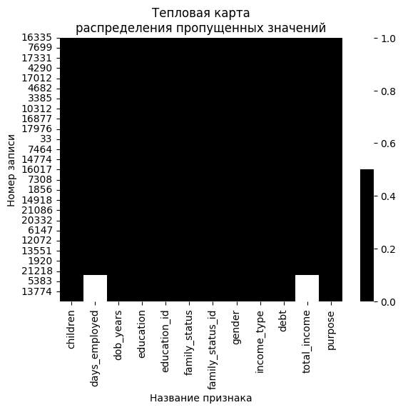

```python
sns.heatmap(data.sort_values(by=['days_employed']).isna(),
            cmap=sns.color_palette(['#000000', '#ffffff']))
plt.title('Тепловая карта\nраспределения пропущенных значений')
plt.xlabel('Название признака')
plt.ylabel('Номер записи')
plt.show()
```

**Промежуточный вывод**

- Набор данных содержит 12 уникальных признаков и 21 525 записей.
- Всего: 258 300 элементов данных.
- Набор данных содержит данные следующего типа:
  - целочисленный — 5 признаков,
  - вещественный — 2 признака,
  - смешанного типа — 5 признаков.
- Все признаки содержат значения (не являются пустыми).
- 10 признаков не содержат пропущенные значения.
- 2 признака содержат пропущенные значения:
  - все пропуски в признаке `days_employed` сопровождаются пропусками в признаке `total_income`.
  - всего в данных 4348 пропущенных значений — около 1,7 % от всех элементов данных.

## Понимание данных

Для проведения исследования надёжности заёмщиков банка собирают данные о каждом из них, включая личную информацию, кредитную историю и другую информацию, которая может быть полезной для анализа.

Обычно рассматривают несколько факторов, которые потенциально могут влиять на факт погашения кредита в срок.

> **Персональные данные клиента** — это любая информация, которая относится к конкретному человеку и позволяет однозначно его идентифицировать.

Так банки могут проводить анализ на предмет различий в заработной плате мужчин и женщин или наличии у них стабильной работы.

`gender` — пол  
Признак является категориальным, бинарным.  
Шкала измерения признака: дихотомическая шкала.

Возраст также может быть фактором, влияющим на принятие решения. Например, молодые люди могут иметь меньше трудового опыта или могут иметь менее стабильный доход, что повышает риск невыплаты кредита. Кроме того, некоторые банки могут устанавливать ограничения возраста заёмщика, например, не выдавать кредиты лицам моложе 18 лет или старше 70 лет.

`dob_years` — возраст (лет)  
Признак является количественным, непрерывным.  
Шкала измерения признака: интервальная шкала.

Однако это не является абсолютной истиной, и в каждом случае необходимо иметь индивидуальный подход к каждому заёмщику. Кроме того, запрет на дискриминацию по полу и возрасту означает, что банки должны основывать свои решения только на факторах, связанных с финансовой надёжностью заёмщика, такими как кредитная история, доход и другие.

> **Уровень образования** отражает достигнутую степень образования и квалификацию человека. Он может включать в себя основное общее или среднее общее образование, среднее профессиональное, высшее образование. Кроме того, человек может иметь присвоенную учёную степень.

Банк может рассматривать уровень образования как один из факторов, свидетельствующих о финансовой надёжности и компетентности заёмщика. Человек с более высоким уровнем образования, как правило, имеет более стабильную и высокооплачиваемую работу. Высокий уровень образования может указывать на способность человека адекватно оценивать финансовые риски. Более образованные люди потенциально могут обладать лучшими навыками в планировании своих финансовых обязательств, что может помочь им более эффективно управлять своими платежами и избегать просрочки по погашению кредита.

`education` — уровень образования  
Признак является категориальным, номинальным.  
Шкала измерения признака: номинальная шкала.

`education_id` — идентификатор уровня образования  
Признак является категориальным, номинальным.  
Шкала измерения признака: номинальная шкала.

> **Семейное положение** представляет собой юридический или социальный статус человека, который описывает его отношения с партнёром, а также наличие или отсутствие детей.

Информация о семейном положении заёмщика может повлиять на решение банка о выдаче кредита, поскольку она предоставляет информацию о его социальной и экономической стабильности. Например, банк может считать, что лицо в браке более надёжно в плане погашения кредита, так как совместный доход и поддержка партнёра могут повысить вероятность своевременной выплаты. Разведение или потеря партнёра, в свою очередь, потенциально могут понизить такую вероятность.

`family_status` — семейное положение  
Признак является категориальным, номинальным.  
Шкала измерения признака: номинальная шкала.

`family_status_id` — идентификатор семейного положения  
Признак является категориальным, номинальным.  
Шкала измерения признака: номинальная шкала.

Наличие детей может повысить финансовую нагрузку на семью заёмщика, что может затруднить своевременное внесение платежей по кредиту.

`children` — количество детей в семье  
Признак является количественным, дискретным.  
Шкала измерения признака: абсолютная шкала.

> **Тип занятости** относится к статусу и способу работы заёмщика. Он может включать в себя такие категории, как наёмный работник, безработный, предприниматель, пенсионер и другие.

Некоторые типы занятости могут считаться более стабильными и надёжными с точки зрения финансовых обязательств. Например, наёмный работник, имеющий постоянный и стабильный доход, может быть рассмотрен банком как потенциально надёжный заёмщик.

Если тип занятости подразумевает более нестабильный доход или наличие рисков, то это может отразиться на способности заёмщика выплатить кредит. Например, предприниматели могут иметь непостоянный доход или более высокий уровень финансовой нестабильности. В таких случаях банк может потребовать дополнительные подтверждения дохода и гарантии.

`income_type` — тип занятости  
Признак является категориальным, номинальным.  
Шкала измерения признака: номинальная шкала.

> **Трудовой стаж** — это период времени, в течение которого человек работает на одном или нескольких рабочих местах.

Банк может рассматривать заёмщика с длительным трудовым стажем как более надёжного, который, вероятнее всего, сможет своевременно возвращать долг, поскольку долгосрочная работа на постоянном месте работы или стабильный трудовой стаж могут быть признаками регулярного поступления финансовых средств заёмщику.

`days_employed` — общий трудовой стаж (дней)  
Признак является количественным, непрерывным.  
Шкала измерения признака: интервальная шкала.

> **Ежемесячный доход** — это сумма денег, которую человек получает каждый месяц в виде заработной платы, пенсии, пособий или других источников.

Информация о ежемесячном доходе заёмщика является одним из ключевых факторов, влияющих на решение банка о выдаче кредита. Банк оценивает способность заёмщика возвратить кредитные средства. Чем выше доход, тем выше вероятность того, что заёмщик будет в состоянии погасить кредит вовремя. Банки склонны считать, что заёмщик, имея достаточный ежемесячный доход, будет способен покрывать ежемесячные платежи по кредиту.

`total_income` — ежемесячный доход (у. е.)  
Признак является количественным, непрерывным.  
Шкала измерения признака: шкала отношений.

> **Цель получения кредита** — это основная причина, по которой заёмщик обращается в банк с просьбой о предоставлении кредитных средств. Часто целями получения кредита являются финансирование покупки недвижимости, автомобиля, получение образование, инвестирование в бизнес или погашение других долгов.

Банки могут оценивать риск и вероятность возврата кредита в зависимости от цели, для которой он берётся. Некоторые цели, например, финансирование образования или покупка недвижимости, могут считаться более надёжными, так как они связаны с потенциальным улучшением кредитоспособности заёмщика или могут потенциально приносить доход.

`purpose` — цель получения кредита  
Признак является категориальным, номинальным.  
Шкала измерения признака: номинальная шкала.

Ключевой параметр, который поможет оценить надёжность заёмщика, является **отсутствие задолженности** по текущим кредитам. Отслеживание факта задолженности заёмщика по кредитам позволяет банку оценить уровень риска, связанного с выдачей займа данному заёмщику. Задолженность заёмщика по предыдущим кредитам может свидетельствовать о его ненадёжности и неплатёжеспособности.

`debt` — факт того, имел ли заёмщик задолженность по кредитам  
Признак является категориальным, бинарным.  
Шкала измерения признака: дихотомическая шкала.

## Предобработка данных

### Обработка аномальных значений

**Общий трудовой стаж**

В данных встречаются отрицательные значения количества дней трудового стажа среди значений признака `days_employed`. Заменим их на положительные значения, равные по абсолютной величине.

```python
data['days_employed'] = data['days_employed'].abs()

sum(data['days_employed'] < 0)
```

```
0
```

Среди медианных значений трудового стажа `days_employed`, полученных для каждого типа занятости, у двух типов (безработные и пенсионеры) наблюдаются резко отличающиеся большие значения. Возможно, таким образом авторы набора данных разделяли все данные на две группы. Исправить такие значения без дополнительной информации не удастся.

```python
data.groupby('income_type')['days_employed'].agg('median')
```

```
income_type
безработный        366413.652744
в декрете            3296.759962
госслужащий          2689.368353
компаньон            1547.382223
пенсионер          365213.306266
предприниматель       520.848083
сотрудник            1574.202821
студент               578.751554
Name: days_employed, dtype: float64
```

### Обработка пропусков

```python
total = data.isna().sum().sort_values(ascending=False)
percent = (data.isna().sum() /
           data.isna().count() * 100).round(1).sort_values(ascending=False)
pd.concat([total, percent], axis=1, keys=['Всего пропусков', '%'])
```

|  | Всего пропусков | % |
| --- | --- | --- |
| days_employed | 2174 | 10.1 |
| total_income | 2174 | 10.1 |
| children | 0 | 0.0 |
| dob_years | 0 | 0.0 |
| education | 0 | 0.0 |
| education_id | 0 | 0.0 |
| family_status | 0 | 0.0 |
| family_status_id | 0 | 0.0 |
| gender | 0 | 0.0 |
| income_type | 0 | 0.0 |
| debt | 0 | 0.0 |
| purpose | 0 | 0.0 |

В признаках `days_employed`, `total_income` есть пропущенные значения — по 10 % от всех значений.

Наиболее вероятно, что на сумму дохода и общий трудовой стаж сильнее всего будет влиять тип занятости, поэтому заполним пропуски в признаках `total_income` и `days_employed` медианным значением, рассчитанным для каждого уникального значения признака `income_type` среди известных значений признаков `total_income` и `days_employed`.

#### Ежемесячный доход

```python
for t in data['income_type'].unique():
    data.loc[(data['income_type'] == t) & (data['total_income'].isna()), 'total_income'] = \
    data.loc[(data['income_type'] == t), 'total_income'].median()

data['income_type'].isna().sum()
```

```
0
```

#### Общий трудовой стаж

```python
for t in data['income_type'].unique():
    data.loc[(data['income_type'] == t) & (data['days_employed'].isna()), 'days_employed'] = \
    data.loc[(data['income_type'] == t), 'days_employed'].median()

data.isna().sum().sum()
```

```
0
```

### Обработка аномальных значений (продолжение)

#### Количество детей в семье

```python
data['children'].sort_values().unique()
```

```
array([-1,  0,  1,  2,  3,  4,  5, 20], dtype=int64)
```

```python
len(data[(data['children'] == -1) | (data['children'] == 20)])
```

```
123
```

Среди значений признака `children` есть два аномальных значения — 20 и −1. Поскольку не представляется возможным восстановить реальные значения, удалим строки, содержащие такие аномальные значения.

```python
data.shape
```

```
(21525, 12)
```

```python
data = data[(data['children'] != -1) & (data['children'] != 20)]
data['children'].sort_values().unique()
```

```
array([0, 1, 2, 3, 4, 5], dtype=int64)
```

```python
data.shape
```

```
(21402, 12)
```

#### Пол

```python
data['gender'].unique()
```

```
array(['F', 'M', 'XNA'], dtype=object)
```

```python
len(data[data['gender'] == 'XNA'])
```

```
1
```

Среди значений признака `gender` есть аномальное значение "XNA". Такое значение встречается в одной записи. Поскольку не представляется возможным восстановить настоящее значение, удалим запись.

```python
data = data[data['gender'] != 'XNA']
data['gender'].unique()
```

```
array(['F', 'M'], dtype=object)
```

```python
data.shape
```

```
(21401, 12)
```

#### Возраст

```python
data['dob_years'].sort_values().unique()
```

```
array([ 0, 19, 20, 21, 22, 23, 24, 25, 26, 27, 28, 29, 30, 31, 32, 33, 34,
       35, 36, 37, 38, 39, 40, 41, 42, 43, 44, 45, 46, 47, 48, 49, 50, 51,
       52, 53, 54, 55, 56, 57, 58, 59, 60, 61, 62, 63, 64, 65, 66, 67, 68,
       69, 70, 71, 72, 73, 74, 75], dtype=int64)
```

```python
len(data[data['dob_years'] == 0])
```

```
100
```

Среди значений признака `dob_years` есть аномальное значение 0. Очевидно, что возраст клиента банка не может быть ниже возраста наступления дееспособности в полном объёме. Поскольку не представляется возможным восстановить настоящие значения возраста, удалим записи.

```python
data = data[data['dob_years'] != 0]
data['dob_years'].sort_values().unique()
```

```
array([19, 20, 21, 22, 23, 24, 25, 26, 27, 28, 29, 30, 31, 32, 33, 34, 35,
       36, 37, 38, 39, 40, 41, 42, 43, 44, 45, 46, 47, 48, 49, 50, 51, 52,
       53, 54, 55, 56, 57, 58, 59, 60, 61, 62, 63, 64, 65, 66, 67, 68, 69,
       70, 71, 72, 73, 74, 75], dtype=int64)
```

```python
data.shape
```

```
(21301, 12)
```

### Изменение типов данных

```python
data.dtypes
```

```
children              int64
days_employed       float64
dob_years             int64
education            object
education_id          int64
family_status        object
family_status_id      int64
gender               object
income_type          object
debt                  int64
total_income        float64
purpose              object
dtype: object
```

Значения признаков `total_income` и `days_employed` имеют большое число знаков после запятой. Очевидно, что точность определения значений этих признаков гораздо ниже. Поэтому округлим значения и приведём их к целочисленному типу.

```python
data['total_income'] = data['total_income'].round().astype('int')
data['days_employed'] = data['days_employed'].round().astype('int')

data.dtypes
```

```
children             int64
days_employed        int32
dob_years            int64
education           object
education_id         int64
family_status       object
family_status_id     int64
gender              object
income_type         object
debt                 int64
total_income         int32
purpose             object
dtype: object
```

### Обработка текстовых значений

Среди значений признака `education` есть одинаковые, но они записаны буквами различного регистра: прописными и строчными. Приведём значения признака к нижнему регистру.

```python
data['education'] = data['education'].str.lower()
data['education'].sort_values().unique()
```

```
array(['высшее', 'начальное', 'неоконченное высшее', 'среднее',
       'ученая степень'], dtype=object)
```

Также поступим и со значениями признака `family_status` — приведём их к нижнему регистру.

```python
data['family_status'] = data['family_status'].str.lower()
data['family_status'].sort_values().unique()
```

```
array(['в разводе', 'вдовец / вдова', 'гражданский брак',
       'женат / замужем', 'не женат / не замужем'], dtype=object)
```

### Обработка дубликатов

```python
data.duplicated().sum()
```

```
71
```

```python
data[data.duplicated(keep=False)].sort_values(by=['purpose', 'dob_years']).head(10)
```

|  | children | days_employed | dob_years | education | education_id | family_status | family_status_id | gender | income_type | debt | total_income | purpose |
| --- | --- | --- | --- | --- | --- | --- | --- | --- | --- | --- | --- | --- |
| 8178 | 0 | 365213 | 64 | среднее | 1 | женат / замужем | 0 | F | пенсионер | 0 | 118514 | автомобиль |
| 13639 | 0 | 365213 | 64 | среднее | 1 | женат / замужем | 0 | F | пенсионер | 0 | 118514 | автомобиль |
| 120 | 0 | 1574 | 46 | среднее | 1 | женат / замужем | 0 | F | сотрудник | 0 | 142594 | высшее образование |
| 16378 | 0 | 1574 | 46 | среднее | 1 | женат / замужем | 0 | F | сотрудник | 0 | 142594 | высшее образование |
| 1511 | 0 | 365213 | 58 | высшее | 0 | не женат / не замужем | 4 | F | пенсионер | 0 | 118514 | дополнительное образование |
| 8583 | 0 | 365213 | 58 | высшее | 0 | не женат / не замужем | 4 | F | пенсионер | 0 | 118514 | дополнительное образование |
| 12389 | 0 | 365213 | 64 | среднее | 1 | женат / замужем | 0 | F | пенсионер | 0 | 118514 | дополнительное образование |
| 20702 | 0 | 365213 | 64 | среднее | 1 | женат / замужем | 0 | F | пенсионер | 0 | 118514 | дополнительное образование |
| 3609 | 0 | 365213 | 64 | среднее | 1 | женат / замужем | 0 | F | пенсионер | 0 | 118514 | жилье |
| 18428 | 0 | 365213 | 64 | среднее | 1 | женат / замужем | 0 | F | пенсионер | 0 | 118514 | жилье |

В наборе данных есть полные дубликаты. Всего 71 запись. Удалим дубликаты.

```python
data.shape
```

```
(21301, 12)
```

```python
data.drop_duplicates(inplace=True)
data.duplicated().sum()
```

```
0
```

```python
data.shape
```

```
(21230, 12)
```

### Обогащение данных

#### Категоризация данных

Создание признака "Уровень дохода".

На основании значений признака `total_income` сформируем признак `total_income_category`, отражающий уровень дохода каждого клиента в соответствии с таблицей:

| Ежемесячный доход, у. е. | Уровень дохода |
| --- | --- |
| 30 000 и менее | E |
| от 30 000 до 50 000 | D |
| от 50 000 до 200 000 | C |
| от 200 000 до 1 000 000 | B |
| более 1 000 000 | A |

```python
def categorize_income(income):
    '''
    Функция, определяющая уровень дохода.

    Принимает значение ежемесячного дохода.
    Возвращает строку с категорией уровня дохода.
    '''

    try:
        if income <= 30000:
            return 'E'
        elif 30000 < income <= 50000:
            return 'D'
        elif 50000 < income <= 200000:
            return 'C'
        elif 200000 < income <= 1000000:
            return 'B'
        elif income > 1000000:
            return 'A'
    except:
        pass
```

```python
data['total_income_category'] = data['total_income'].apply(categorize_income)
data['total_income_category'].sort_values().unique()
```

```
array(['A', 'B', 'C', 'D', 'E'], dtype=object)
```

Создание признака "Группа целей получения кредита".

```python
data['purpose'].sort_values().unique()
```

```
array(['автомобили', 'автомобиль', 'высшее образование',
       'дополнительное образование', 'жилье',
       'заняться высшим образованием', 'заняться образованием',
       'на покупку автомобиля', 'на покупку подержанного автомобиля',
       'на покупку своего автомобиля', 'на проведение свадьбы',
       'недвижимость', 'образование', 'операции с жильем',
       'операции с коммерческой недвижимостью',
       'операции с недвижимостью', 'операции со своей недвижимостью',
       'покупка жилой недвижимости', 'покупка жилья',
       'покупка жилья для сдачи', 'покупка жилья для семьи',
       'покупка коммерческой недвижимости', 'покупка недвижимости',
       'покупка своего жилья', 'получение высшего образования',
       'получение дополнительного образования', 'получение образования',
       'приобретение автомобиля', 'профильное образование',
       'ремонт жилью', 'свадьба', 'свой автомобиль',
       'сделка с автомобилем', 'сделка с подержанным автомобилем',
       'строительство жилой недвижимости', 'строительство недвижимости',
       'строительство собственной недвижимости', 'сыграть свадьбу'],
      dtype=object)
```

На основании значений признака `purpose` сформируем признак `purpose_category`, в котором обобщены цели получения кредита. Всего выделим четыре цели и в соответствии с ними определим категории:

- *`операции с автомобилем`*,
- *`операции с недвижимостью`*,
- *`проведение свадьбы`*,
- *`получение образования`*.

```python
def categorize_purpose(row):
    '''
    Функция, определяющая обобщённую цель получения кредита.

    Принимает строку с целью.
    Возвращает строку с обобщённой целью.
    '''

    try:
        if 'автом' in row:
            return 'операции с автомобилем'
        elif 'жил' in row or 'недвиж' in row:
            return 'операции с недвижимостью'
        elif 'свад' in row:
            return 'проведение свадьбы'
        elif 'образов' in row:
            return 'получение образования'
    except:
        return 'нет категории'
```

```python
data['purpose_category'] = data['purpose'].apply(categorize_purpose)
data['purpose_category'].sort_values().unique()
```

```
array(['операции с автомобилем', 'операции с недвижимостью',
       'получение образования', 'проведение свадьбы'], dtype=object)
```

```python
data.shape
```

```
(21230, 14)
```

### Удаление признаков

```python
for edu_id in data['education_id'].unique():
    print(edu_id, '-', data.loc[data['education_id'] == edu_id, 'education'].unique())
```

```
0 - ['высшее']
1 - ['среднее']
2 - ['неоконченное высшее']
3 - ['начальное']
4 - ['ученая степень']
```

```python
for status_id in data['family_status_id'].unique():
    print(status_id, '-', data.loc[data['family_status_id'] == status_id, 'family_status'].unique())
```

```
0 - ['женат / замужем']
1 - ['гражданский брак']
2 - ['вдовец / вдова']
3 - ['в разводе']
4 - ['не женат / не замужем']
```

Значения признаков `education_id` и `family_status_id` являются номинальными и повторяют шкалы номинальных признаков `education` и `family_status`, соответственно. Поскольку признаки не несут дополнительной информации, удалим их.

```python
data.drop(['education_id', 'family_status_id'], axis=1, inplace=True)
data.columns.sort_values()
```

```
Index(['children', 'days_employed', 'debt', 'dob_years', 'education',
       'family_status', 'gender', 'income_type', 'purpose', 'purpose_category',
       'total_income', 'total_income_category'],
      dtype='object')
```

```python
data.shape
```

```
(21230, 12)
```

**Промежуточный вывод**

- Выполнена предварительная обработка данных.
- В результате предварительной обработки данных:
  - обработаны аномальные значения, противоречащие физической природе данных,
  - заполнены пропуски наиболее подходящим значением,
  - типы данных изменены в соответствии с требуемой точностью значений признаков,
  - обнаружены и удалены полные дубликаты,
  - сохранено 98,6 % записей исходного набора данных,
  - данные обогащены путём категоризации значений существующих признаков.

## Исследовательский анализ данных

### Описательный анализ

Предварительно зададим функцию, рассчитывающую описательные статистики.

```python
def descriptive_statistics(values, label):
    '''
    Описательная статистика переменной, измеряемой в количественной шкале.

    Принимает значения признака и название признака.
    Возвращает DataFrame с набором статистик.

    '''

    df = pd.DataFrame([
        values.count(),
        len(values.unique()),
        values.min(),
        values.median() - 1.5 * (values.quantile(q=.75) -
                                 values.quantile(q=.25)),
        values.quantile(q=.25).round(2),
        (values.mode()).to_list(),
        values.median().round(2),
        values.mean().round(2),
        values.quantile(q=.75).round(2),
        values.median() + 1.5 * (values.quantile(q=.75) -
                                 values.quantile(q=.25)),
        values.max(),
        values.max() - values.min(),
        values.quantile(q=.75) - values.quantile(q=.25)
    ],
        index=['кол-во значений', 'кол-во уникальных', 'мин.',
               '-1.5IQR', '25 %', 'мода', 'медиана',
               'среднее ариф.', '75 %', '+1.5IQR', 'макс.',
               'размах', 'межквартильный размах'],
        columns=[label])

    return df
```

#### Пол

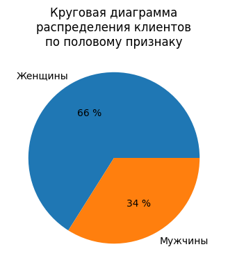

```python
data['gender'].value_counts().rename(
    index={'F': 'Женщины',
           'M': 'Мужчины'}
).plot(
    kind='pie',
    figsize=(4, 4),
    title='Круговая диаграмма' +
          '\nраспределения клиентов' +
          '\nпо половому признаку',
    label='',
    autopct='%.0f %%')
plt.show()
```

```python
pd.DataFrame(data['gender'].value_counts().rename(
    index={'F': 'Женщины',
           'M': 'Мужчины'})) \
    .reset_index() \
    .rename(columns={'gender': 'Пол',
                     'count': 'Количество клиентов'}) \
    .set_index('Пол').T
```

| Пол | Женщины | Мужчины |
| --- | --- | --- |
| Количество клиентов | 14021 | 7209 |

- Значения определены для всех записей.
- Женщин среди клиентов — 14 021, мужчин — 7209.
- Количество женщин относится к количеству мужчин как 2 : 1.

#### Возраст

```python
descriptive_statistics(data['dob_years'], 'Возраст, лет')
```

|  | Возраст, лет |
| --- | --- |
| кол-во значений | 21230 |
| кол-во уникальных | 57 |
| мин. | 19 |
| -1.5IQR | 13.0 |
| 25 % | 33.0 |
| мода | [35] |
| медиана | 43.0 |
| среднее ариф. | 43.48 |
| 75 % | 53.0 |
| +1.5IQR | 73.0 |
| макс. | 75 |
| размах | 56 |
| межквартильный размах | 20.0 |

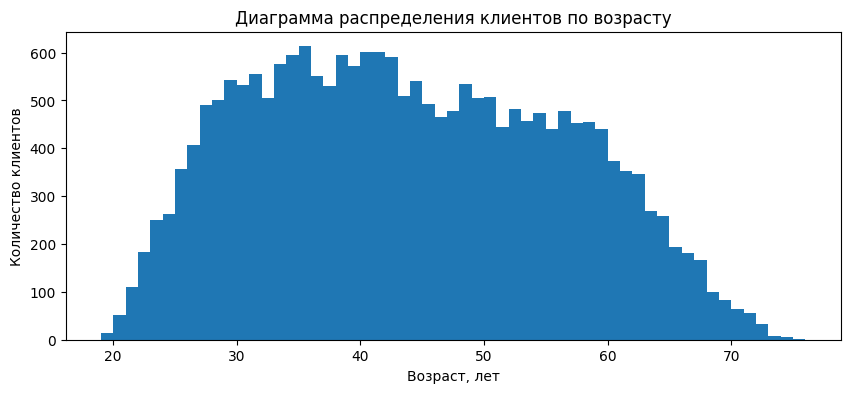

```python
plt.figure(figsize=(10, 4))
plt.title('Диаграмма распределения клиентов по возрасту')
plt.hist(data['dob_years'], bins=[x for x in range(19, 77)])
plt.xlabel('Возраст, лет')
plt.ylabel('Количество клиентов')
plt.show()
```

- Значения определены для всех записей.
- Значения определены с точностью до 1 года.
- Для 21 230 записей встречается 57 различных уникальных значений.
- Минимальное значение — 19 лет, максимальное значение — 75 лет.
- Мода — 35 лет, медиана — 43 года.
- Распределение трапециевидное. Количество клиентов в возрасте от 30 до 60 лет практически одинаковое.
- Половина всех клиентов достигло возраста 33–53 лет.

#### Уровень образования

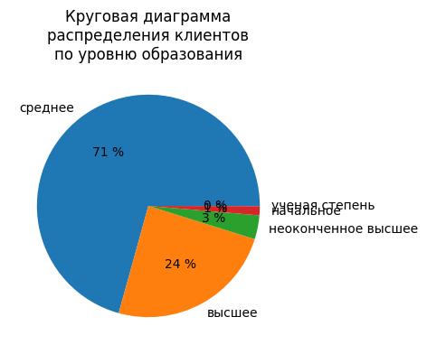

```python
data['education'].value_counts().plot(
    kind='pie',
    figsize=(4, 4),
    title='Круговая диаграмма' +
          '\nраспределения клиентов' +
          '\nпо уровню образования',
    label='',
    autopct='%.0f %%')
plt.show()
```

```python
pd.DataFrame(data['education'].value_counts()) \
    .reset_index() \
    .rename(columns={'education': 'Уровень образования',
                     'count': 'Количество клиентов'}) \
    .set_index('Уровень образования').T
```

| Уровень образования | среднее | высшее | неоконченное высшее | начальное | ученая степень |
| --- | --- | --- | --- | --- | --- |
| Количество клиентов | 15012 | 5192 | 738 | 282 | 6 |

- Значения определены для всех записей.
- Для 21 230 записей встречается 5 различных уникальных значений.
- Мода — среднее образование, её частота — 15 012. Это 71 % всех записей.
- Второе по распространённости — высшее образование. Такое значение встречается в 5192 записях — это 24 % всех записей.
- В оставшихся 5 % записей упоминается неоконченное высшее, начальное образование и присуждённая учёная степень.

#### Семейное положение

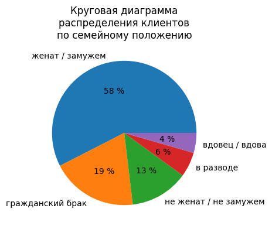

```python
data['family_status'].value_counts().plot(
    kind='pie',
    figsize=(4, 4),
    title='Круговая диаграмма' +
          '\nраспределения клиентов' +
          '\nпо семейному положению',
    label='',
    autopct='%.0f %%')
plt.show()
```

```python
pd.DataFrame(data['family_status'].value_counts()) \
    .reset_index() \
    .rename(columns={'family_status': 'Семейное положение',
                     'count': 'Количество клиентов'}) \
    .set_index('Семейное положение').T
```

| Семейное положение | женат / замужем | гражданский брак | не женат / не замужем | в разводе | вдовец / вдова |
| --- | --- | --- | --- | --- | --- |
| Количество клиентов | 12213 | 4112 | 2780 | 1179 | 946 |

- Значения определены для всех записей.
- Для 21 230 записей встречается 5 различных уникальных значений.
- Мода — женат/замужем, её частота 12 213. Это 58 % всех записей.
- Второе по распространённости семейное положение — гражданский брак. Встречается в 4112 записях — это 19 % всех записей.
- Третье по распространённости семейное положение — не женат/не замужем. Таких записей — 2780. Это 13 % от всех записей.
- На клиентов, находящихся в разводе, приходится 1179 записей (или 6 % всех записей).
- Оставшиеся 4 % (946 записей) приходится на вдовствующих клиентов.

#### Количество детей в семье

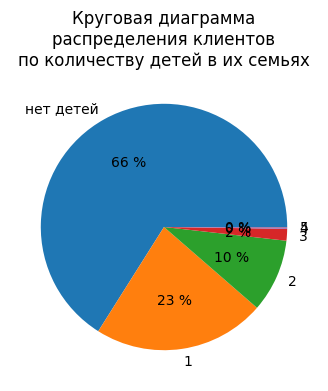

```python
data['children'].value_counts().rename(
    index={0: 'нет детей'}
).plot(
    kind='pie',
    figsize=(4, 4),
    title='Круговая диаграмма' +
          '\nраспределения клиентов' +
          '\nпо количеству детей в их семьях',
    label='',
    autopct='%.0f %%')
plt.show()
```

```python
pd.DataFrame(data['children'].value_counts()) \
    .reset_index() \
    .rename(columns={'children': 'Количество детей',
                     'count': 'Количество клиентов'}) \
    .set_index('Количество детей').T
```

| Количество детей | 0 | 1 | 2 | 3 | 4 | 5 |
| --- | --- | --- | --- | --- | --- | --- |
| Количество клиентов | 14021 | 4792 | 2039 | 328 | 41 | 9 |

#### Тип занятости

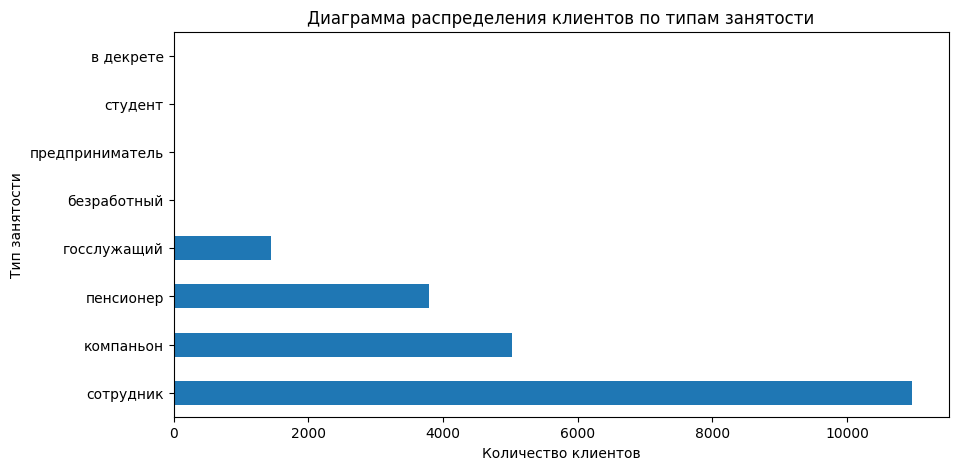

```python
data['income_type'].value_counts().plot(
    kind='barh',
    figsize=(10, 5),
    title='Диаграмма распределения клиентов по типам занятости',
    xlabel='Количество клиентов',
    ylabel='Тип занятости'
)
plt.show()
```

```python
pd.DataFrame(data['income_type'].value_counts()) \
    .reset_index() \
    .rename(columns={'income_type': 'Тип занятости',
                     'count': 'Количество клиентов'}) \
    .set_index('Тип занятости')
```

| Тип занятости | Количество клиентов |
| --- | --- |
| сотрудник | 10961 |
| компаньон | 5026 |
| пенсионер | 3792 |
| госслужащий | 1445 |
| безработный | 2 |
| предприниматель | 2 |
| студент | 1 |
| в декрете | 1 |

- Значения определены для всех записей.
- Для 21 230 записей встречается 8 уникальных значений.
- Мода — сотрудник, её частота — 10 961. Это 51 % всех записей.
- В два раза меньше записей со значением типа занятости "компаньон" — 5026, 24 % всех записей.
- Пенсионеров среди клиентов — 3792 (18 %), а госслужащих — 1445 (7 %).
- Безработные, предприниматели, студенты и находящиеся в декретном отпуске — единичные случаи.

#### Общий трудовой стаж

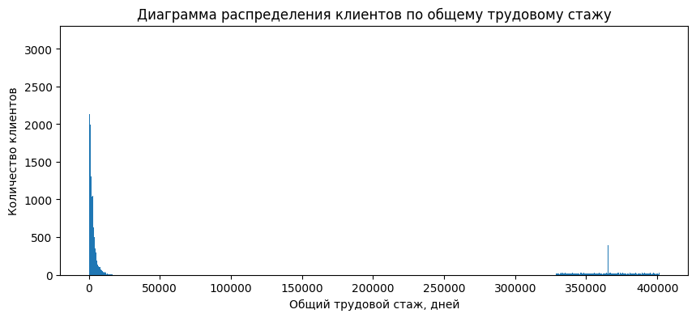

```python
plt.figure(figsize=(10, 4))
plt.title('Диаграмма распределения клиентов по общему трудовому стажу')
plt.hist(data['days_employed'], bins=1000)
plt.xlabel('Общий трудовой стаж, дней')
plt.ylabel('Количество клиентов')
plt.show()
```

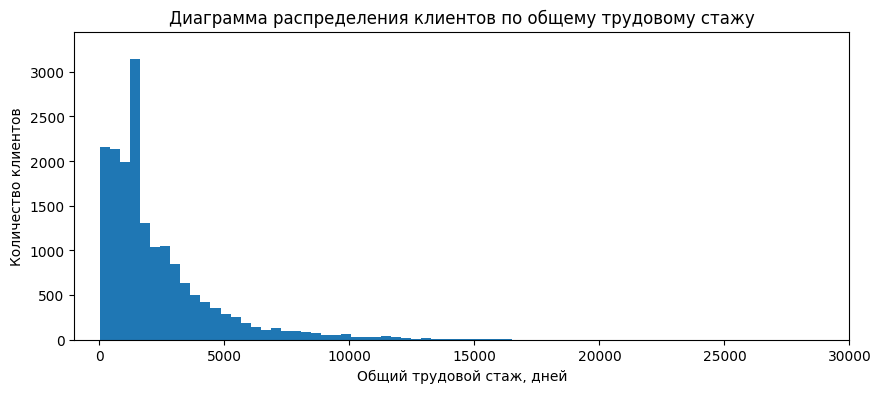

```python
plt.figure(figsize=(10, 4))
plt.title('Диаграмма распределения клиентов по общему трудовому стажу')
plt.hist(data['days_employed'], bins=1000)
plt.xlabel('Общий трудовой стаж, дней')
plt.ylabel('Количество клиентов')
plt.xlim(-1000, 30000)
plt.ylim(0, 3450)
plt.show()
```

```python
data.groupby('income_type')['days_employed'].agg('median')
```

```
income_type
безработный        366413.5
в декрете            3297.0
госслужащий          2689.0
компаньон            1547.0
пенсионер          365213.0
предприниматель       521.0
сотрудник            1574.0
студент               579.0
Name: days_employed, dtype: float64
```

- Значения определены для всех записей.
- В распределении значений отчётливо наблюдают две группы значений от 0 до 30 тыс. распределение похоже на экспоненциальное, и в районе 365 тыс. унимодальное. Такое распределение значений, очевидно, сгенерировано авторами набора данных синтетически для того, чтобы заполнить значения этого признака для клиентов, являющихся пенсионерами или безработными, у которых не будет учитываться их трудовой стаж.

#### Ежемесячный доход

```python
descriptive_statistics(data['total_income'], 'Ежемесячный доход, у. е.')
```

|  | Ежемесячный доход, у. е. |
| --- | --- |
| кол-во значений | 21230 |
| кол-во уникальных | 18403 |
| мин. | 20667 |
| -1.5IQR | 10198.375 |
| 25 % | 107550.5 |
| мода | [142594] |
| медиана | 142594.0 |
| среднее ариф. | 165384.37 |
| 75 % | 195814.25 |
| +1.5IQR | 274989.625 |
| макс. | 2265604 |
| размах | 2244937 |
| межквартильный размах | 88263.75 |

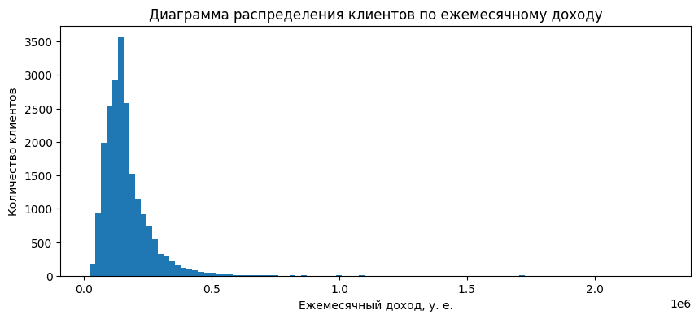

```python
plt.figure(figsize=(10, 4))
plt.title('Диаграмма распределения клиентов по ежемесячному доходу')
plt.hist(data['total_income'], bins=100)
plt.xlabel('Ежемесячный доход, у. е.')
plt.ylabel('Количество клиентов')
plt.show()
```

- Значения определены для всех записей.
- Значения определены с точностью до 1 у. е.
- Для 21 230 записей встречается 18 403 различных уникальных значений.
- Минимальное значение — 20 667 у. е., максимальное значение — 2 265 604 у. е.
- Мода — 142 594 у. е., медиана — 142 594 у. е., среднее арифметическое — 165 384 у. е.
- Распределение унимодальное, смещено влево, с длинным "хвостом" справа.
- Половина всех клиентов имеет ежемесячный доход 107–196 тыс. у. е.

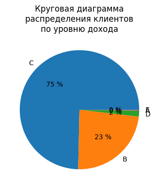

```python
data['total_income_category'].value_counts().plot(
    kind='pie',
    figsize=(4, 4),
    title='Круговая диаграмма' +
          '\nраспределения клиентов' +
          '\nпо уровню дохода',
    label='',
    autopct='%.0f %%')
plt.show()
```

```python
pd.DataFrame(data['total_income_category'].value_counts()) \
    .reset_index() \
    .rename(columns={'total_income_category': 'Уровень дохода',
                     'count': 'Количество клиентов'}) \
    .set_index('Уровень дохода').sort_index()
```

| Уровень дохода | Количество клиентов |
| --- | --- |
| A | 25 |
| B | 4987 |
| C | 15849 |
| D | 347 |
| E | 22 |

- Для каждой записи определено значение уровня дохода.
- Все 5 уникальных значений.
- Модой является средний уровень дохода, её частота — 15 849. Это 75 % всех записей.
- Следующими по распространённости находятся записи о клиентах с уровнем дохода выше среднего — 4987 записей (или 23 % всех записей).
- На оставшиеся 2 % приходятся записи о клиентах с доходом ниже среднего (347 записей или более 1 % всех записей) и всего по несколько десятков записей на клиентов с низким или высоким уровнем дохода.

#### Цель получения кредита

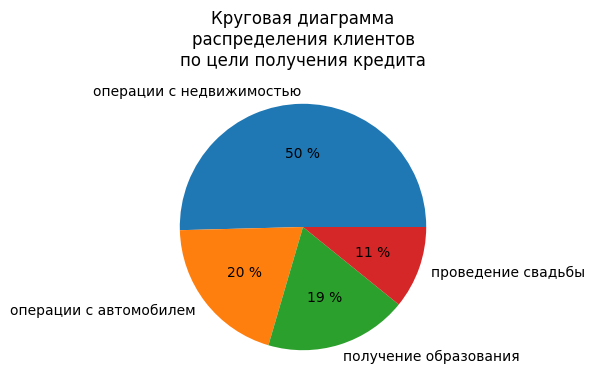

```python
data['purpose_category'].value_counts().plot(
    kind='pie',
    figsize=(4, 4),
    title='Круговая диаграмма' +
          '\nраспределения клиентов' +
          '\nпо цели получения кредита',
    label='',
    autopct='%.0f %%')
plt.show()
```

```python
pd.DataFrame(data['purpose_category'].value_counts()) \
    .reset_index() \
    .rename(columns={'purpose_category': 'Цель получения кредита',
                     'count': 'Количество клиентов'}) \
    .set_index('Цель получения кредита')
```

| Цель получения кредита | Количество клиентов |
| --- | --- |
| операции с недвижимостью | 10703 |
| операции с автомобилем | 4258 |
| получение образования | 3970 |
| проведение свадьбы | 2299 |

#### Факт наличия задолженности по кредиту

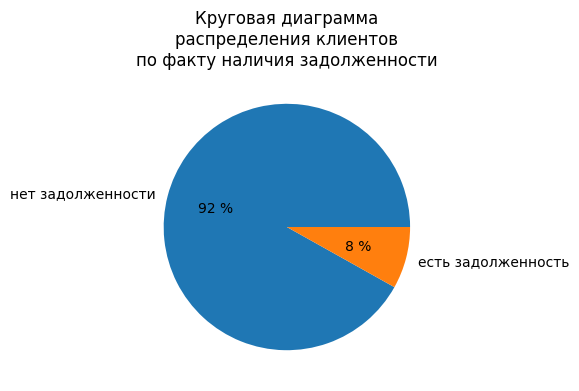

```python
data['debt'].value_counts().rename(
    index={0: 'нет задолженности',
           1: 'есть задолженность'}
).plot(
    kind='pie',
    figsize=(4, 4),
    title='Круговая диаграмма' +
          '\nраспределения клиентов' +
          '\nпо факту наличия задолженности',
    label='',
    autopct='%.0f %%')
plt.show()
```

```python
pd.DataFrame(data['debt'].value_counts().rename(
    index={0: 'нет задолженности',
           1: 'есть задолженность'})) \
    .reset_index() \
    .rename(columns={'debt': 'Факт наличия задолженности',
                     'count': 'Количество клиентов'}) \
    .set_index('Факт наличия задолженности')
```

| Факт наличия задолженности | Количество клиентов |
| --- | --- |
| нет задолженности | 19506 |
| есть задолженность | 1724 |

- Значения определены для всех значений.
- Количество клиентов (19 506), у которых нет задолженности, относится к количеству клиентов (1724), у которых есть задолженность, почти как 11 : 1.

### Корреляционный анализ

Исследовать зависимости между параметрами заёмщика и наличием задолженности по возврату кредита в срок будем путём расчёта доли заёмщиков, имеющих задолженность перед банком, для сгруппированных по каждому значению параметра данных. Сравним полученные значения.

```python
def show_table(value, name):
    '''
    Функция расчёта доли должников.

    Принимает название признака и подпись этого признака.
    Возвращает сводную таблицу со значениями количества заёмщиков,
    количества должников и доли должников среди агрегированных
    данных по каждому значению принимаемого признака.
    '''

    table = data.pivot_table(index=[value],
                             values='debt',
                             aggfunc=['count', 'sum', 'mean']).reset_index()
    table['mean'] = round(table['mean'] * 100, 1)
    table.columns = [name, 'Количество заёмщиков',
                     'Количество должников', 'Доля должников, %']
    table = table.set_index(name).sort_values(by='Доля должников, %',
                                              ascending=False)

    return table
```

#### Наличие задолженности — пол клиента

```python
show_table('gender', 'Пол').rename(index={'F': 'Женщины', 'M': 'Мужчины'})
```

| Пол | Количество заёмщиков | Количество должников | Доля должников, % |
| --- | --- | --- | --- |
| Мужчины | 7209 | 740 | 10.3 |
| Женщины | 14021 | 984 | 7.0 |

- Среди заёмщиков-мужчин количество должников достигает 10,3 %, среди заёмщиков-женщин — только 7,0 %.
- Отношение доли должников среди мужчин к доле должников среди женщин равно $\frac{10,3\ \%}{7,0\ \%} \approx 1,5$.

#### Наличие задолженности — возраст клиента

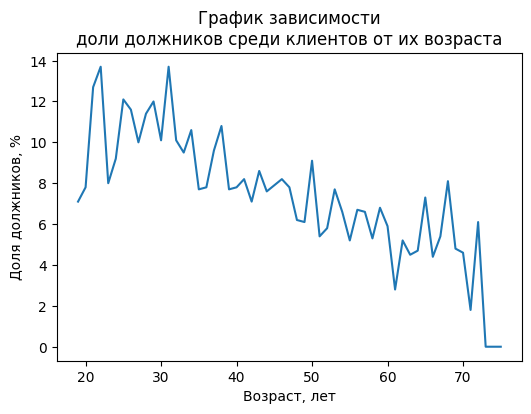

```python
table = show_table('dob_years', 'Возраст').sort_index()

plt.figure(figsize=(6, 4))
plt.title('График зависимости'+
          '\nдоли должников среди клиентов от их возраста')
plt.plot(table['Доля должников, %'])
plt.xlabel('Возраст, лет')
plt.ylabel('Доля должников, %')
plt.show()
```

```python
t = show_table('dob_years', 'Возраст').reset_index()

pd.DataFrame({
    'Возраст, лет': ['младше 30', 'от 30 до 40', 'от 40 до 50', 'от 50 до 60', '60 и старше'],
    'Среднее значение доли должников, %': [
        t.loc[t['Возраст'] < 30, 'Доля должников, %'].mean().round(1),
        t.loc[(t['Возраст'] >= 30) & (t['Возраст'] < 40), 'Доля должников, %'].mean().round(1),
        t.loc[(t['Возраст'] >= 40) & (t['Возраст'] < 50), 'Доля должников, %'].mean().round(1),
        t.loc[(t['Возраст'] >= 50) & (t['Возраст'] < 60), 'Доля должников, %'].mean().round(1),
        t.loc[t['Возраст'] >= 60, 'Доля должников, %'].mean().round(1)
    ]
}).set_index('Возраст, лет')
```

| Возраст, лет | Среднее значение доли должников, % |
| --- | --- |
| младше 30 | 10.5 |
| от 30 до 40 | 9.8 |
| от 40 до 50 | 7.5 |
| от 50 до 60 | 6.5 |
| 60 и старше | 4.1 |

- На графике зависимости доли должников от их возраста хоть и заметно большое количество шумов, всё же наблюдается тенденция к снижению доли должников среди заёмщиков одного возраста с увеличением значения возраста.
- Так если среднее значение доли должников среди заёмщиков до 30 лет достигает 10,5 %, от 30 до 40 лет — 9,8 %, то уже среди должников от 40 до 50 лет это значение составляет 7,5 %, от 50 до 60 лет — 6,5 %, а среди должников старше 60 лет среднее значение доли должников составляет всего 4 %.

#### Наличие задолженности — уровень образования клиента

```python
show_table('education', 'Уровень образования')
```

| Уровень образования | Количество заёмщиков | Количество должников | Доля должников, % |
| --- | --- | --- | --- |
| начальное | 282 | 31 | 11.0 |
| неоконченное высшее | 738 | 68 | 9.2 |
| среднее | 15012 | 1348 | 9.0 |
| высшее | 5192 | 277 | 5.3 |
| ученая степень | 6 | 0 | 0.0 |

- Доли должников среди заёмщиков, имеющих разные уровни образования, разные.
- Наибольшая доля должников — 11 % — среди заёмщиков, имеющих только начальный уровень образования.
- Почти одинаковая доля должников среди заёмщиков, имеющих среднее или неоконченное высшее образование, — 9,0 % и 9,2 %, соответственно.
- Меньше всего задолжников среди заёмщиков, имеющих высшее образование, — всего 5,3 %.
- Отношение долей должников среди заёмщиков, имеющих среднее или неоконченное высшее образование, к доле должников среди заёмщиков с высшим образованием равно $\frac{9,0\ \%}{5,3\ \%} \approx 1,7$ и $\frac{9,2\ \%}{5,3\ \%} \approx 1,7$, соответственно.
- Отношение доли должников с начальным образованием к доле должников с высшим образованием равно $\frac{11,0\ \%}{5,3\ \%} \approx 2,1$.
- Выборка из заёмщиков с присвоенной учёной степенью не является репрезентативной. Хотя среди заёмщиков, имеющих учёную степень, нет должников и доля должников составляет 0 %, но, если в эту выборку войдёт ещё один заёмщик, у которого будет задолженность перед банком, доля должников может стать равной $\frac{1}{6+1} \times 100\ \% \approx 14\ \%$.
- Таким образом, можно заметить, что среди более образованных заёмщиков количество должников будет ниже, чем среди менее образованных заёмщиков.

#### Наличие задолженности — семейное положение

```python
show_table('family_status', 'Семейное положение')
```

| Семейное положение | Количество заёмщиков | Количество должников | Доля должников, % |
| --- | --- | --- | --- |
| не женат / не замужем | 2780 | 272 | 9.8 |
| гражданский брак | 4112 | 383 | 9.3 |
| женат / замужем | 12213 | 923 | 7.6 |
| в разводе | 1179 | 84 | 7.1 |
| вдовец / вдова | 946 | 62 | 6.6 |

- Среди заёмщиков, находящихся в разном семейном положении, доли должников разные.
- Более 9 % должников среди заёмщиков, не состоящих в браке или состоящих в гражданском браке, — 9,8 % и 9,3 %, соответственно.
- Более 7 % должников среди заёмщиков, состоящих в браке или уже разведённых, — 7,6 % и 7,1 %, соответственно.
- Меньше всего должников среди вдовствующих заёмщиков — 6,6 %.
- Отношение доли должников среди неженатых или состоящих в гражданском браке заёмщиков к доле должников среди вдовствующих заёмщиков составляет $\frac{9,8\ \%}{6,6\ \%} \approx 1,5$ и $\frac{9,3\ \%}{6,6\ \%} \approx 1,4$, соответственно.
- Отношение доли должников среди женатых или разведённых заёмщиков к доле должников среди вдовствующих заёмщиков составляет $\frac{7,6\ \%}{6,6\ \%} \approx 1,2$ и $\frac{7,1\ \%}{6,6\ \%} \approx 1,1$, соответственно.
- Таким образом, среди заёмщиков, не обременённых социальной ответственностью в форме юридически оформленного брака, доля должников выше, нежели среди заёмщиков, которые состоят в браке. А вот доля должников среди заёмщиков, которые развелись или потеряли партнёра, ниже, чем среди заёмщиков, состоящих в браке.

#### Наличие задолженности — количество детей в семье

```python
show_table('children', 'Количество детей')
```

| Количество детей | Количество заёмщиков | Количество должников | Доля должников, % |
| --- | --- | --- | --- |
| 4 | 41 | 4 | 9.8 |
| 2 | 2039 | 194 | 9.5 |
| 1 | 4792 | 441 | 9.2 |
| 3 | 328 | 27 | 8.2 |
| 0 | 14021 | 1058 | 7.5 |
| 5 | 9 | 0 | 0.0 |

#### Наличие задолженности — тип занятости

```python
show_table('income_type', 'Тип занятости')
```

| Тип занятости | Количество заёмщиков | Количество должников | Доля должников, % |
| --- | --- | --- | --- |
| в декрете | 1 | 1 | 100.0 |
| безработный | 2 | 1 | 50.0 |
| сотрудник | 10961 | 1048 | 9.6 |
| компаньон | 5026 | 373 | 7.4 |
| госслужащий | 1445 | 86 | 6.0 |
| пенсионер | 3792 | 215 | 5.7 |
| предприниматель | 2 | 0 | 0.0 |
| студент | 1 | 0 | 0.0 |

#### Наличие задолженности — общий трудовой стаж

Для анализа зависимости между общим трудовым стажем и наличием задолженности перед банком округлим значения трудового стажа до 1000 дней. Такой подход позволит выделить группы значений трудового стажа, то есть позволит агрегировать записи. Для каждой группы значения стажа затем рассчитаем долю должников, предварительно выделив записи, относящиеся к заёмщикам, являющимся рабочим населением: сотрудникам, компаньонам, госслужащим.

```python
data['days_employed'] = data['days_employed'].round(-3)
data['days_employed'].sample(5)
```

```
19816      1000
20711    353000
12188         0
20458         0
16537      2000
Name: days_employed, dtype: int32
```

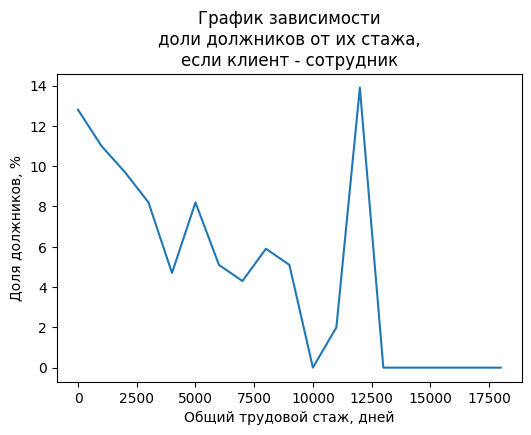

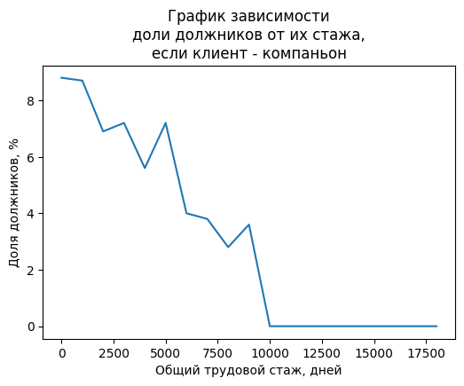

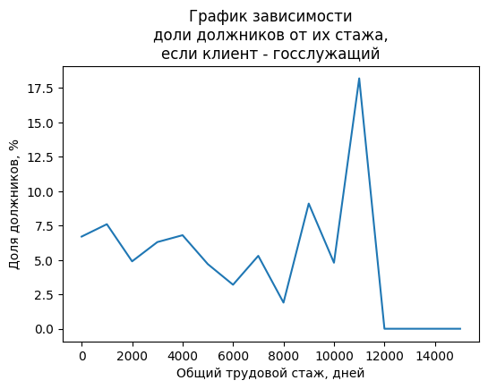

```python
for i in ['сотрудник', 'компаньон', 'госслужащий']:
    table = data[data['income_type'] == i].pivot_table(index=['days_employed'],
                                                       values='debt',
                                                       aggfunc=['mean'])
    table['mean'] = round(table['mean'] * 100, 1).sort_index()

    plt.figure(figsize=(6, 4))
    plt.title('График зависимости'+
              '\nдоли должников от их стажа,' +
              f'\nесли клиент - {i}')
    plt.plot(table)
    plt.xlabel('Общий трудовой стаж, дней')
    plt.ylabel('Доля должников, %')
    plt.show()
```

- Данный подход является грубой попыткой обнаружить тренд в зависимости доли должников от общего трудового стажа в выделенных группах трудового стажа. Для более точной оценки такой зависимости необходимо собрать данные о большем количестве клиентов банка.
- Во всех трёх случаях: когда заёмщики являются сотрудниками коммерческих компаний, компаньонами-соучредителями, госслужащими — наблюдается тренд к уменьшению доли должников с увеличением общего трудового стажа.
- Для сотрудников частных компаний и госслужащих наблюдается также всплеск доли должников в области 10–12 тыс. дней трудового стажа. Вероятно, такое поведение графика обусловлено малым количеством значений и требует уточнения после сбора большего количества данных.

#### Наличие задолженности — ежемесячный доход

```python
show_table('total_income_category', 'Уровень дохода').sort_index()
```

| Уровень дохода | Количество заёмщиков | Количество должников | Доля должников, % |
| --- | --- | --- | --- |
| A | 25 | 2 | 8.0 |
| B | 4987 | 353 | 7.1 |
| C | 15849 | 1346 | 8.5 |
| D | 347 | 21 | 6.1 |
| E | 22 | 2 | 9.1 |

#### Наличие задолженности — цель получения кредита

```python
show_table('purpose_category', 'Цель получения кредита')
```

| Цель получения кредита | Количество заёмщиков | Количество должников | Доля должников, % |
| --- | --- | --- | --- |
| операции с автомобилем | 4258 | 397 | 9.3 |
| получение образования | 3970 | 369 | 9.3 |
| проведение свадьбы | 2299 | 181 | 7.9 |
| операции с недвижимостью | 10703 | 777 | 7.3 |

- Доля должников среди групп заёмщиков, получивших кредит на разные цели, разная.
- Наибольшая доля должников и почти одинаковая среди заёмщиков, получивших кредит на операции с автомобилем или для получения образования, — 9,3 %.
- Доля должников среди заёмщиков, получивших кредитные средства для проведения свадьбы, уже меньше и составляет 7,9 %.
- Меньше всего значение доли должников среди заёмщиков, получивших кредит на операции с недвижимостью, — 7,3 %.
- Отношение доли должников среди заёмщиков, получивших кредит для проведения свадьбы, к доле должников среди заёмщиков, получивших кредит на операции с недвижимостью, равно $\frac{7,9\ \%}{7,3\ \%} \approx 1,1$.
- Отношение долей должников среди заёмщиков, получивших кредит на операции с автомобилем или для получения образования, равно $\frac{9,3\ \%}{7,3\ \%} \approx 1,3$.

## Общий вывод

В процессе исследования были проанализированы записи о 21 230 заёмщиках. 92 % клиентов (19 506) не имеют перед банком задолженностей, 8 % заёмщиков (1724) являются должниками. Таким образом, количество клиентов без задолженности почти в 11 раз больше клиентов с задолженностью.

Среднее значение доли должников среди клиентов банка достигает 8 %. Поэтому если доля должников, найденная по сгруппированным данным, составляет менее 8 %, то будем считать заёмщиков из этой группы надёжными, если более 8 % — ненадёжными.

***Поло-возрастные характеристики клиентов***

Среди заёмщиков женщин (14 021) в 2 раза больше, чем мужчин (7209). Однако доля должников среди мужчин в 1,5 раза выше, чем среди женщин. Женщины являются более надёжными заёмщиками — доля должников среди них составляет 7,0 %. Мужчин можно считать ненадёжными заёмщиками, поскольку доля должников среди них составляет 10,3 %.

***Уровень образования***

Среди клиентов банка люди с разным уровнем образования: от начального до высшего, встречаются даже с учёной степенью, но таких человек только несколько. Высшее образование почти у четверти клиентов (24 %), ещё 3 % имеют неполное высшее образование. Основная масса заёмщиков (71 %) — люди со средним уровнем образования. Начальное образование только у 1 % заёмщиков.

Надёжными являются заёмщики только с высшим образованием — доля должников среди них составляет 5,3 %. Клиенты со средним, неоконченным высшим и начальным образованием являются ненадёжными заёмщиками, поскольку доли должников среди них составляют 9,0 %, 9,2 % и 11,0 %, соответственно. Выборка из заёмщиков, имеющих присвоенную учёную степень, не является репрезентативной.

***Семейное положение***

Больше половины клиентов (58 %) состоят в официальном браке, ещё 19 % живут в гражданском браке. Неженатых только 13 %. Клиенты, находящиеся в разводе, составляют 6 %. Оставшиеся 4 % приходятся на вдовствующих клиентов.

Надёжных заёмщиков банка можно найти среди вдовствующих или находящихся в разводе клиентов — доли должников среди них составляют 6,6 % и 7,1 %, соответственно. Всё ещё надёжными можно считать клиентов, состоящих в официальном браке. Доля должников среди них составляет 7,6 %. Ненадёжными являются неженатые клиенты или клиенты, состоящие в гражданском браке, поскольку доли должников среди них достигают 9,8 % и 9,3 %, соответственно.

***Количество детей в семье***

Доля должников среди заёмщиков, у которых нет детей, составляет 7,5 %, поэтому их всё ещё можно считать надёжными заёмщиками. Клиенты, у которых есть дети, являются ненадёжными заёмщиками. Доля должников среди них составляет 9,2 %. Причём можно ожидать наличие тенденции, что с ростом количества детей в семье доли имеющих задолженность перед банком тоже будут увеличиваться. Но для более подробного исследования нужно больше данных. Исходя из располагаемых данных, нельзя однозначно установить зависимость между значением доли должников и количество детей в семье.

***Тип занятости***

Около половины всех клиентов (51 %) являются рядовыми сотрудниками коммерческих компаний. Почти четверть клиентов (24 %) являются компаньонами — соучредителями компаний. Госслужащими являются только 7 % клиентов. К неработающему населению относятся 18 % клиентов, являющихся пенсионерами. Безработные, предприниматели, студенты и находящиеся в декретном отпуске — единичные случаи.

Надёжными заёмщиками являются неработающие клиенты — пенсионеры. Доля должников среди них составляет 5,7 %. Заёмщиков среди работающего населения можно считать менее надёжными, поскольку доля должников среди них составляет 8,6 %. Но среди них госслужащих следует отнести к надёжным заёмщикам — доля должников среди них составляет 6,0 %. К всё ещё надёжным заёмщикам можно отнести и компаньонов, так как доля должников среди них составляет 7,4 %. А вот сотрудников коммерческих компаний можно считать ненадёжными, ведь доля должников среди них самая высокая среди групп работающего населения и составляет 9,6 %.

***Ежемесячный доход***

Ежемесячный доход клиентов составляет от 20 тыс. до 2265 тыс. у. е. Медианный доход — 143 тыс. у. е., однако среднее арифметическое значение — 165 тыс. у. е., что обусловлено длинным "хвостом" справа в распределении значений ежемесячного дохода. Межквартильный интервал изменяется от 107 тыс. до 196 тыс. у. е.

По уровню дохода три четверти клиентов (75 %) имеют средний уровень (50–200 тыс. у. е.), около четверти (23 %) — доход выше среднего (200 тыс.–1 млн у. е.). На оставшиеся 2 % приходятся записи о клиентах с доходом ниже среднего (347 записей или более 1 % всех записей) и всего по несколько десятков записей на клиентов с низким или высоким уровнем дохода.

Клиентов со средним доходом уже можно считать ненадёжными, поскольку доля должников среди них составляет 8,5 %. Среди заёмщиков с уровнем дохода выше среднего и высоким (более 200 тыс. у. е.) доля должников составляет 7,1 %, а среди заёмщиков с уровнем дохода ниже среднего и низким (50 тыс. у. е. и меньше) доля должников составляет 6,2 %. Поэтому их можно считать надёжными заёмщиками. Для отдельной оценки надёжности заёмщиков с низким или высоким уровнем дохода необходимо собрать больше данных.

***Цель получения кредита***

Половина всех клиентов (50 %) получила кредитные средства на операции с недвижимостью. Близкие количества заёмщиков получили кредитные средства на операции с автомобилем (20 %) и для получения образования (19 %). Для проведения свадьбы кредит получали 11 % заёмщиков.

Ненадёжными являются заёмщики, получившие кредитные средства на операции с автомобилем или для получения образования. Доли должников среди таких заёмщиков составляют 9,3 %. Всё ещё надёжными можно назвать заёмщиков, получивших кредит для проведения свадьбы, поскольку доля должников среди них составляет 7,9 %. И надёжными можно назвать заёмщиков, получивших кредит на операции с недвижимостью. Среди них 7,3 % должников.